# Prius Wait Times

If you live in a wealthy, liberal town like Boulder, CO, you’ve likely seen your fair share of Toyota Prius. Heck, you might even own one. While taking my son on a walk, I decided to collect a little data. I used my iPhone stopwatch to record wait times between seeing Prii. I walked at a near-constant speed, along a more or less linear transect along 13th Street, from Arapahoe to Spruce. I recorded for 10 minutes, hitting the “lap” button each time I saw a Prius (any year, parked or driving). There is some risk of counting one vehicle multiple times, but because I walked in one direction and only recorded for 10 minutes, I assume the risk is relatively low (unless Prius owners love driving so much, they just go out and do laps around city blocks – quite possible).

Below is some code I’ve thrown together to analyze the data I collected. The objective here is to predict the expected wait times between Prius sightings, and to quantify uncertainty in this expectation. Along the way, we’ll check out the max time you should expect to wait, and test a few assumptions of the model.

Load the relevant libraries:

```r
library(magrittr)
library(tidyverse)
library(lubridate)
library(rstan)
rstan_options(auto_write = TRUE)
options(mc.cores = parallel::detectCores())
```

Load the data (lubridate package to convert weird minute-seconds to numeric integers).

```r
wt_times <- c("00:11", "01:08", "00:06", "02:06", "00:06", "00:16",
              "00:00", "00:06", "01:43", "00:13", "00:05", "00:13",
              "01:59", "00:45", "00:27", "00:51", "00:02") %>%
  ms %>%
  as.numeric  %>%
  data_frame %>%
  set_colnames("wait")

n_obs <- length(wt_times$wait)
```

First observation, I saw 17 Prii in 10 minutes – that strikes me a lot! I make no attempt to calculate the total number of Prii from these observations, but that seems like a possible feat with some effort.

Let’s take a look at the distribution (it took some time, but I’m pretty solidly parked in `ggplot2` train these days).

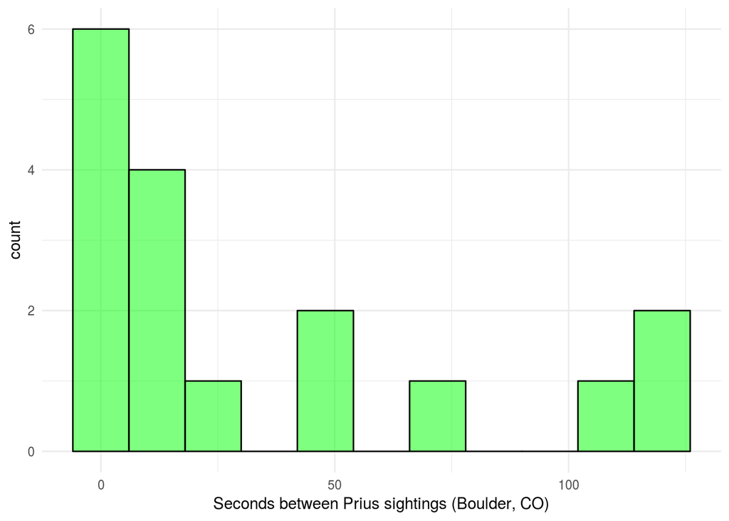

```r
wt_times %>% ggplot(aes(x = wait)) +
  stat_bin(binwidth = 12, alpha = 0.5,
                 fill = "green", colour = "black") +
  xlab("Seconds between Prius sightings (Boulder, CO)") +
  theme_minimal()
```

Based on the graph and similarity to other problems, it seems reasonable to assume wait times are exponentially distributed. I’ll also assume that the observations are dictated by a single rate parameter (easy to imagine density of Prii vary across neighborhoods).

To be totally overkill, I’m going to fit the model using stan, to numerically approximate the posterior distrbution of the exponential rate parameter. I’m pretty sure there’s an analytical solution for the posterior in this case (gamma distributed conjugacy?), but I’m just gonna do the stan thing, since it generalizes well to more compelx problems, and because I’m still pretty bad at real math.

Usually I’d write the stan code in a seperate file because it makes life easier, but I’ll write it directly into this post as a string to keep this post self-contained. I’m using a gamma prior for the exponential rate parameter, and I’m putting the shape and scale parameters as input to the stan model to make assessment of prior sensitivity easier.

```r
stan_string <- "

  data{
    int<lower = 0> N;
    real<lower = 0> y[N];
    real<lower = 0> pr_shape;
    real<lower = 0> pr_scale;
  }

  parameters{
    real<lower = 0> beta;
  }

  model{
    beta ~ gamma(pr_shape, pr_scale);
    target += exponential_lpdf(y | beta);
  }
"

stan_exp <- stan_model(model_code=stan_string)
```

[output not shown]

Here’s a quick little plot to see what this prior looks like.

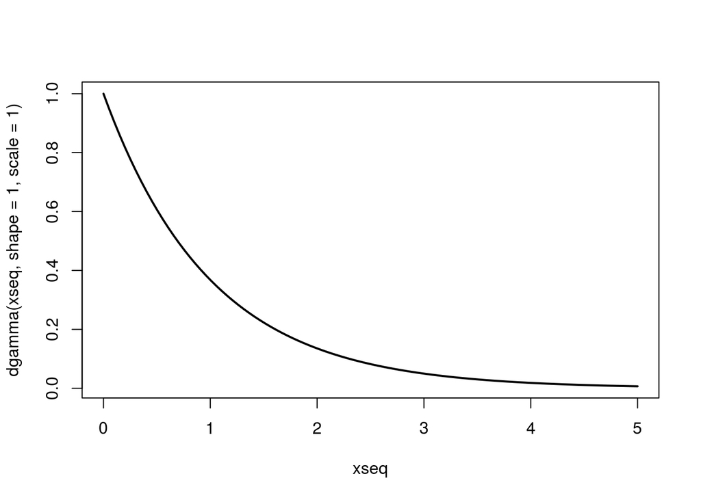

```r
xseq <- seq(0, 5, length.out = 100)
plot(xseq, dgamma(xseq, shape = 1, scale = 1), type = "l", lwd = 2)
```

Bundle the data and run stan.

```r
stan_in <- list(
  y = wt_times$wait,
  N = n_obs,
  pr_shape = 1,
  pr_scale = 3
  )

stan_fit <- sampling(
  object = stan_exp,
  data = stan_in
  )

print(stan_fit)
```

```
## Inference for Stan model: 45ee75e197adc87a0c44d348f2d7068b.
## 4 chains, each with iter=2000; warmup=1000; thin=1;
## post-warmup draws per chain=1000, total post-warmup draws=4000.
##
##        mean se_mean   sd   2.5%    25%    50%    75%  97.5% n_eff Rhat
## beta   0.03    0.00 0.01   0.02   0.02   0.03   0.03   0.04  1470    1
## lp__ -82.21    0.02 0.68 -84.18 -82.38 -81.94 -81.76 -81.71  1364    1
##
## Samples were drawn using NUTS(diag_e) at Wed Aug 30 23:57:53 2017.
## For each parameter, n_eff is a crude measure of effective sample size,
## and Rhat is the potential scale reduction factor on split chains (at
## convergence, Rhat=1).
```

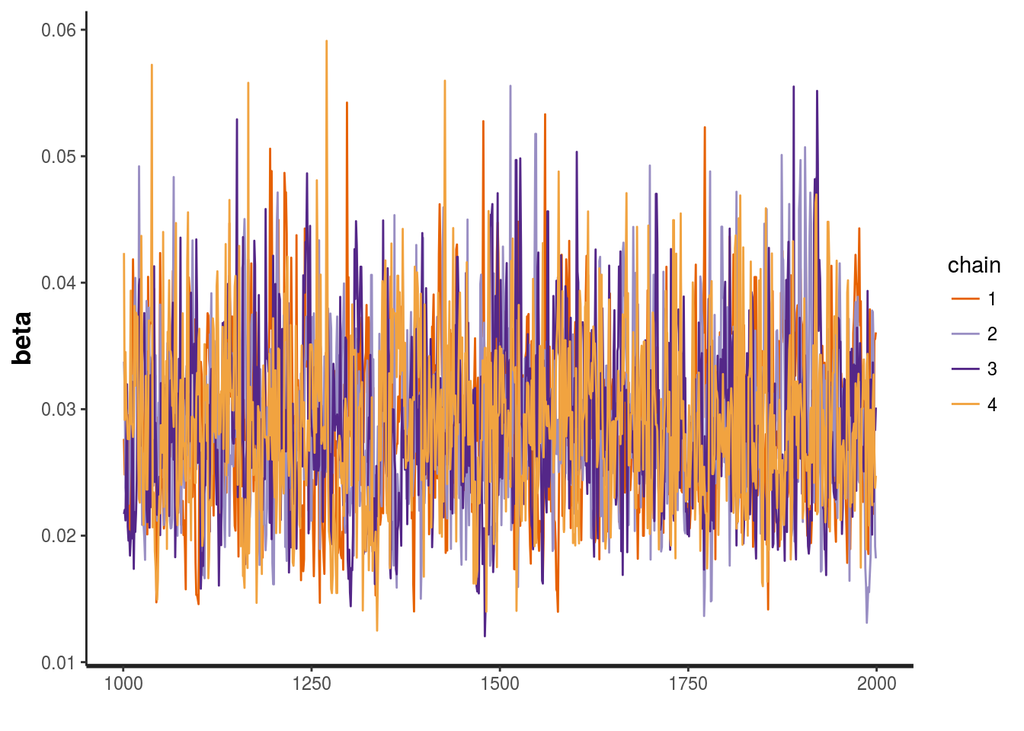

Traceplot looks nice and grassy.

```r
traceplot(stan_fit)
```

This is a tiny model that runs quite quickly. The default of 4000 iterations and 50% warmup is probably more than necessary, but the number of effective samples is good, as are the rhat values being 1. The traceplot looks nice and grassy, without any indications the chains are getting stuck on parameter values. The model returns a few warnings about boundaries, but this is not a concern.

Next we can use the posterior draws to make inferences about the data.

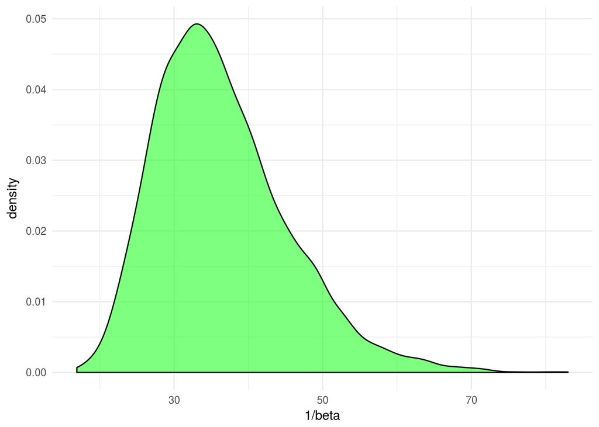

```r
#extract posterior draws from model
exp_post <- extract(stan_fit)

#visualize posterior, but 1/rate, to see expected wait time scale
exp_post %>% data.frame() %>%
  ggplot(aes(x = 1/beta))+
  geom_density(fill = "green", alpha = 0.5) +
  theme_minimal()
```

Compute credible interval of expected wait time

```r
quantile(1/exp_post$beta, c(0.025, 0.975))
```

```
##     2.5%    97.5%
## 22.79554 57.36928
```

We can also easiliy see the probablity that the expected wait time is less than, say, one minute.

```r
mean(1/exp_post$beta < 60)
```

```
## [1] 0.98325
```

Also valuable in a bayesian framework is the ability to conduct posterior predictive checks. We can use posterior draws of the rate parameter, and generate simulated data drawn from and exponential distribution. Perhaps the wait times have more variation than the exponential distribution allows for. We simply need to compare the observed variation to that of the simulated data sets:

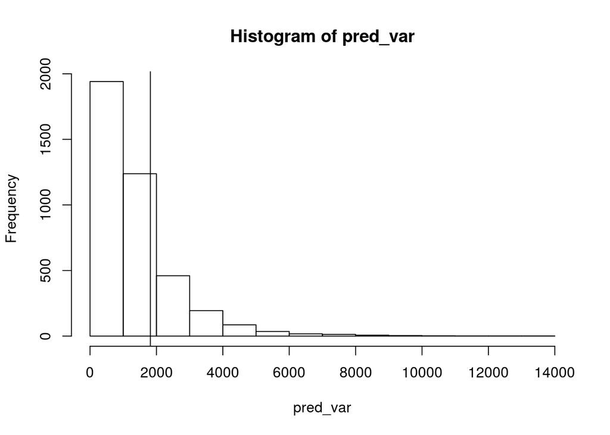

```r
post_pred <- exp_post$beta %>% map(~rexp(n_obs, rate = .x))
pred_var <- post_pred %>% map_dbl(~var(.x))
hist(pred_var)
abline(v = var(wt_times$wait))
```

```r
mean(pred_var > var(wt_times$wait))
```

```
## [1] 0.2365
```

There’s a ~24% probability of simuated data having variation greater than the observed. This isn’t too far off. The nearer to 50%, the more consistent the simulated data and observed. The exponontial distribution model as-is seems fairly adequate.

We can also visually assess the simulated and observed distribution shapes by constructing quantile-quantile plots. I find it a bit easier to see departures by looking at the observed quantiles versus the difference in observed and simulated quantiles:

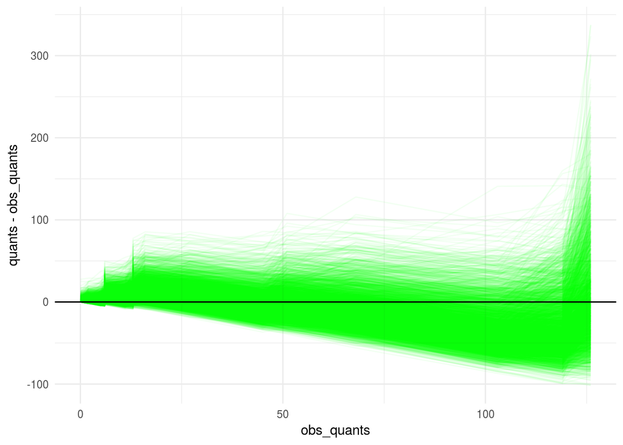

```r
prbs <- seq(0,1, length.out = n_obs)
obs_quants <- quantile(wt_times$wait, prbs)
pred_quants <- post_pred %>% map(~{quantile(.x, prbs) }) %>%
  do.call(cbind, .) %>%
  data.frame() %>%
  gather(key = "draw", "quants") %>%
  group_by(draw) %>%
  mutate(obs_quants = obs_quants)

pred_quants %>% ggplot(aes(x = obs_quants, y = quants - obs_quants, group = draw))+
  geom_line(alpha = 0.05, colour = "green") +
  geom_hline(yintercept = 0) +
  theme_minimal()
```

Ideally, the shape should be relatively flat and centered on zero. The high end gets a little squirrelly, but overall this looks pretty good. The replicated draws to encapsulate zero. We confirm the exponential model is a fairly good one.

Pretty good chance expected wait time is less than one minute. Cool.

We can also get some idea of the max wait time (conditional of the data of course).

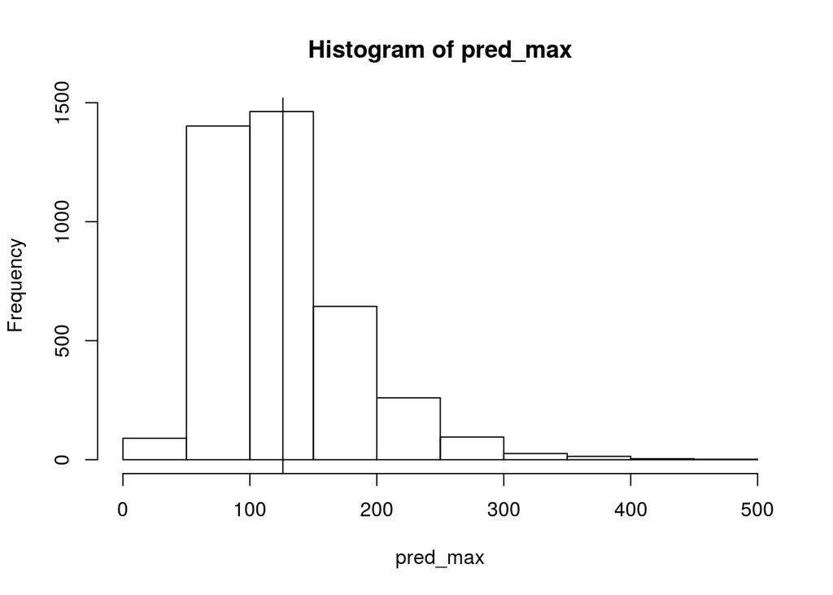

```r
pred_max <- post_pred %>% map_dbl(~max(.x))
hist(pred_max)
abline(v = max(wt_times$wait))
```

```r
quantile(pred_max/60, c(0.025, 0.975))
```

```
##      2.5%     97.5%
## 0.8563136 4.3898222
```

Wow, the model predicts wait times should pretty much always be less than five minutes. That’s a lot of Prii!

Another approach would have been to bootstrap the observations. `tidverse` makes this extra easy. Let’s see how the approximate confidence interval for the expected wait time from the bootstrap compares to the credible interval.

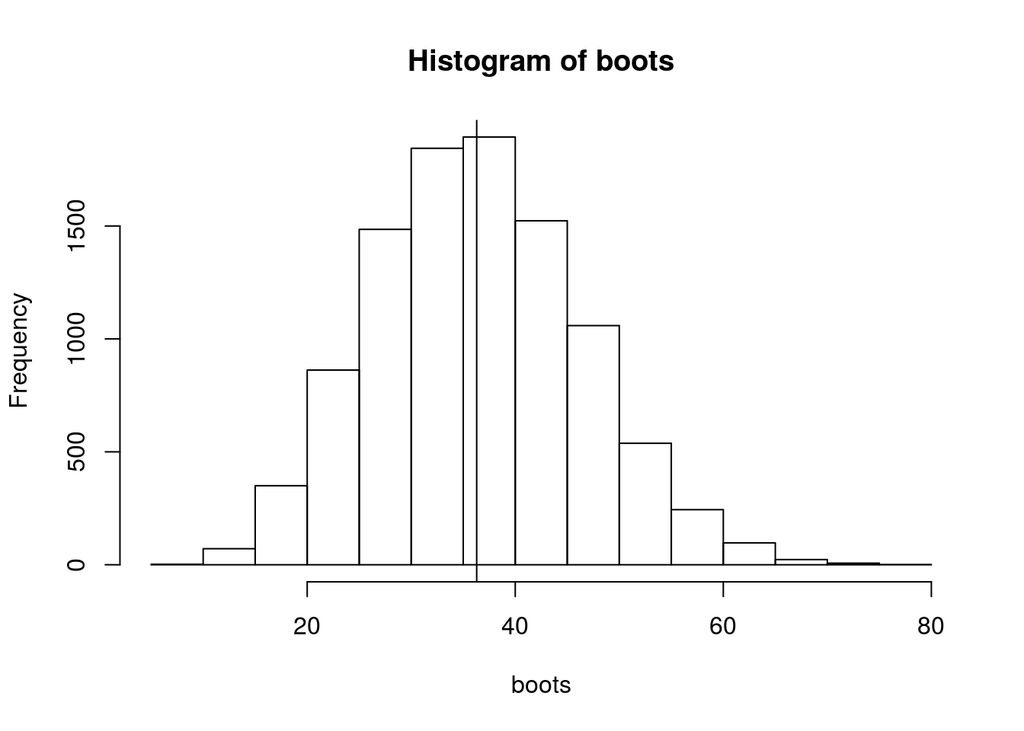

```r
boots <- 1:1e4 %>%
  map_dbl(~{wt_times$wait %>%
  sample(replace = T) %>%
  mean})

hist(boots)
abline(v = mean(wt_times$wait))
```

```r
qnts <- seq(0,1, length.out = 100)
quantile(boots, c(0.025, 0.975))
```

```
##     2.5%    97.5%
## 18.41176 57.23529
```

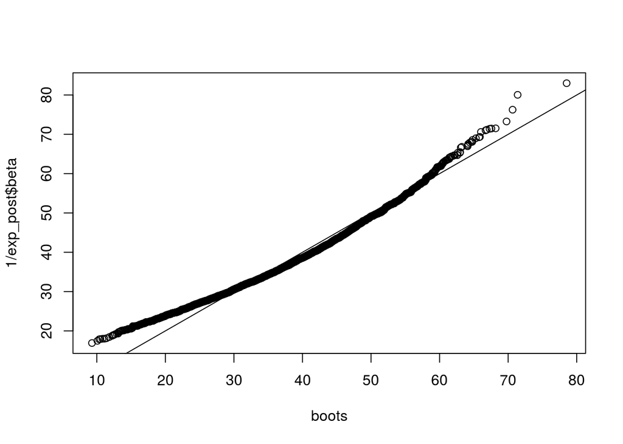

```r
qqplot(boots,1/exp_post$beta)
abline(0,1)
```

The intervals and qqplot both indicate similar predictions, the credible interval is slightly more narrow.

Pretty amazing how common Prii sightings in Boulder are.